# Statistical Computing: Home Assignment 2022

In this notebook we will go over: Part I: function visualization and optimization (using steepest ascent algorithm)

Part II: select a best subset of regressors to explain a sale price for houses with the help of a linear model. In short, the data provide 60 indicators and price of houses, we will try to fit the data into linear models and find the best fit (by using changes in 1-neighborhood method and Bayesian Information Criterion (BIC)).

Part III: Estimate matters of interest (meand and variance) by Monte Carlo simulation and importance sampling.

*Authors:* Thi Lan Anh Nguyen

# Part I.

Consider the following function:

$$f(x,y) = -\frac{((x^2-1)(y^2-4) + x ^2
+y^2 -5)}{(x^2 + y^2 + 1)^2}$$
.

1. Plot the 3D surface of the function f on $[-3,3]^2$ and a contour plot.

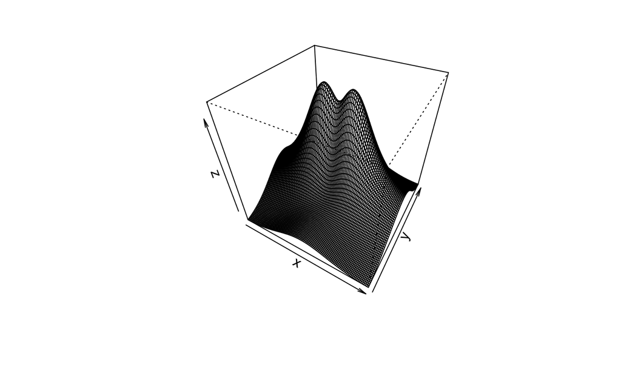

```r
fxy = function(x,y){
  - ( ((x^2-1) *(y^2-4) + x^2 + y^2 -5)/(x^2 + y^2 +1)^2 )
}
x = seq(-3, 3, length = 100)
y = x
z = outer(x, y, fxy)
persp(x, y, z,theta = 30, phi = 40)
```

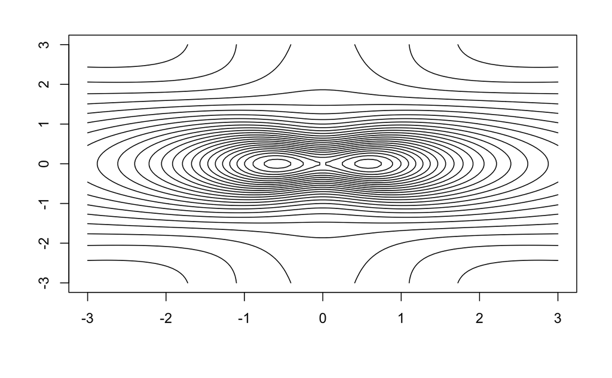

```r
contour(x, y, z, nlevels = 20, drawlabels = F)
```

2. Write R functions for finding the gradient.

```r
fxy = function(x){
  - ( ((x[1]^2 -1) *(x[2]^2 -1) + x[1]^2 + x[2]^2 -5)/(x[1]^2 + x[2]^2 +1)^2 )
}

f.prime = function(x){
    f.prime.dx = 2*x[1]/(x[1]^2 + x[2]^2 +1)^3 *(x[1]^2* x[2]^2 -3*x[1]^2 -x[2]^4 +2*x[2]^2 +1)
    f.prime.dy = 2*x[2]/(x[1]^2 + x[2]^2 +1)^3 *(x[1]^2 *x[2]^2 -x[1]^4 -7*x[1]^2 -2)
    out = matrix(c(f.prime.dx,f.prime.dy),ncol=1)
    return(out)
}
```

3. Find a maximum using the steepest ascent algorithm. Use 100 iterations and perform backtracking for $\alpha$. Choose your own starting values.

```r
# starting point
x = c(-2,-2)
M = diag(-1, 2, 2)
itr = 100
alpha.default = 1
alpha = alpha.default
x.values = matrix(0, itr+1, 2) #initialize a matrix, rows = itr+1, column = 2
x.values[1,] = x #1st element is the starting points

#search loop
for (i in 1:itr){
  hessian.inv = solve(M)
  xt = x - alpha*hessian.inv %*% f.prime(x)
  #Reduce alpha until a correct step is reached - backtracking
  while(fxy(xt) < fxy(x)){
    alpha =alpha/2
    xt = x - alpha*hessian.inv %*% f.prime(x)
  }
  x.values[i+1, ] = x = xt
  alpha = alpha.default #adjust back to = 1
}
```

4. Return the value of the maximum and the gradient. Plot the convergence path on the contour plot.

```r
x              # FINAL ESTIMATE
```

```
              [,1]
[1,] -5.773503e-01
[2,] -1.836320e-07
```

```r
fxy(x)         # OBJECTIVE FUNCTION AT ESTIMATE
```

```
[1] 2.25
```

```r
f.prime(x) # GRADIENT AT ESTIMATE
```

```
             [,1]
[1,] 1.481883e-14
[2,] 6.886200e-07
```

```r
#f.prime is very close to 0
```

# Part II.

The goal of this task is to select a best subset of regressors to explain a sale price for houses with the help of a linear model. The data are contained in houseprice.RData and has already been cleaned. There is a readme file for more details. In order to compare the models (changes in 1-neighborhood) use Bayesian Information Criterion (BIC).

1. Download the dataset “houseprice.RData” and open it in R. Set up 30 iterations and 8 random starts for a random starts local search procedure.

```r
#open file houseprice

# last column is the dependent variable
data.sub = houseprice[, 2:61] # X
y = houseprice[, 62]
n = length(y) # number of obs
m = ncol(data.sub) #number of var
num.starts = 8
runs = matrix(0, num.starts, m)
itr = 30
runs.bic = matrix(0,num.starts,itr)
```

2. Draw 8 random starts from a Bernoulli distribution.Use set.seed(678) and p=0.5.

```r
#Since each run is the bunch of 1 and 0 -> can generate randomly by Benoulli dist
set.seed(678)
for(i in 1:num.starts){
  runs[i,] = rbinom(m, 1, 0.5)
} #-> 8 starts contains 60 predictors with 1 -included and 0 -not included
# at the end, we want to have convergence towards 8 best models then use bic to decide which one is the best

colnames(runs) = colnames(data.sub)
```

3. Perform a random search to find a best linear model with respect to Bayesian Information Criterion (BIC).

```r
for(k in 1:num.starts){
  run.current = runs[k,] # one model each time

  #1. Random start iteration - 1st run
  for(j in 1:itr){
    run.vars = data.sub[, run.current ==1] #only picks those included -> create subset
    g = lm(y~ ., data = run.vars) #fit new model
    run.bic = extractAIC(g, k = log(n))[2]
    run.next = run.current

    # 2. testing all models in 1-neighborhood and selecting the lowest bic
    for(i in 1:m){
      run.step = run.current
      run.step[i] =! run.current[i]
      run.vars = data.sub[, run.step == 1]
      g = lm(y~., run.vars)
      run.step.bic = extractAIC(g, k= log(n))[2]
      if(run.step.bic < run.bic){ #if there's an improvement -> replace -> continue searching
        run.next = run.step
        run.bic = run.step.bic
      }
    } # after this loop, find the min in the k-th in 1-neighborhood model:
    run.current = run.next
    runs.bic[k, j] = run.bic
  }
  runs[k, ] = run.current # update row runs by its newly found model
}
```

4. Display the 8 convergence paths graphically and determine the optimal model. Finally, fit the optimal model.

```r
runs          # selected predictors
```

```
     MSSubClass MSZoning LotArea Street LotShape LandContour Utilities LotConfig LandSlope Neighborhood Condition1
[1,]          0        0       1      1        0           0         0         0         0            1          0
[2,]          0        0       1      1        0           0         0         0         0            1          0
[3,]          0        0       1      1        0           0         0         0         0            1          0
[4,]          0        0       1      1        0           0         0         0         0            1          0
[5,]          0        0       1      1        0           0         0         0         0            1          0
[6,]          0        0       1      1        0           0         0         0         0            1          0
[7,]          0        0       1      0        0           0         0         0         0            1          0
[8,]          0        0       1      1        0           0         0         0         0            1          0
     Condition2 BldgType HouseStyle OverallQual OverallCond YearBuilt YearRemodAdd RoofStyle RoofMatl Exterior1st
[1,]          1        1          0           1           1         1            0         0        1           0
[2,]          1        1          0           1           1         1            0         0        1           0
[3,]          1        1          0           1           1         1            0         0        1           0
[4,]          1        1          0           1           1         1            0         0        1           0
[5,]          1        1          0           1           1         1            0         0        1           0
```

[output cut: 39 more lines]

```r
runs.bic    # BIC values
```

```
         [,1]     [,2]     [,3]     [,4]     [,5]     [,6]     [,7]     [,8]     [,9]    [,10]    [,11]    [,12]
[1,] 30550.19 30465.22 30389.50 30347.98 30310.34 30274.75 30247.41 30220.74 30195.56 30170.30 30147.89 30127.59
[2,] 30511.25 30389.85 30313.23 30266.93 30235.66 30203.01 30170.69 30140.10 30119.46 30099.39 30085.31 30073.35
[3,] 30366.70 30316.02 30277.55 30244.53 30217.04 30190.07 30161.23 30138.57 30121.23 30105.95 30095.23 30087.94
[4,] 30867.87 30641.34 30538.23 30429.36 30349.62 30296.55 30249.77 30214.31 30184.51 30159.20 30134.90 30113.44
[5,] 30933.55 30569.94 30470.92 30398.05 30324.01 30253.35 30218.40 30197.33 30176.92 30157.44 30139.79 30103.95
[6,] 30522.51 30457.43 30377.35 30321.39 30273.34 30242.38 30212.48 30185.02 30165.58 30146.66 30133.75 30120.70
[7,] 31041.48 30785.99 30641.73 30556.29 30479.66 30418.45 30369.12 30325.65 30296.47 30269.53 30243.72 30217.69
[8,] 31014.13 30738.88 30583.92 30494.64 30403.99 30352.54 30312.36 30272.69 30242.98 30195.65 30167.27 30143.86
        [,13]    [,14]    [,15]    [,16]    [,17]    [,18]    [,19]    [,20]    [,21]    [,22]    [,23]    [,24]
[1,] 30108.46 30090.76 30077.02 30064.61 30054.51 30047.22 30039.98 30032.78 30025.65 30019.64 30014.74 30012.71
[2,] 30066.13 30058.99 30051.88 30044.82 30037.98 30031.27 30026.61 30023.43 30021.45 30020.77 30020.28 30015.05
[3,] 30080.66 30073.38 30066.11 30058.88 30051.87 30044.94 30038.10 30032.23 30027.80 30024.54 30020.92 30018.55
[4,] 30092.70 30073.58 30066.30 30059.04 30051.86 30044.77 30037.70 30030.83 30025.09 30019.07 30016.35 30013.87
[5,] 30090.27 30077.18 30069.90 30062.63 30055.52 30048.49 30041.63 30035.08 30031.00 30025.29 30022.27 30019.99
[6,] 30111.24 30104.00 30096.76 30089.55 30082.40 30075.41 30068.44 30061.51 30055.29 30050.34 30046.58 30042.91
[7,] 30194.83 30172.71 30152.34 30137.20 30120.80 30105.78 30093.07 30085.81 30078.65 30071.54 30064.53 30057.52
[8,] 30130.83 30122.13 30114.85 30107.59 30100.50 30067.21 30058.84 30051.72 30044.76 30037.90 30031.09 30024.80
        [,25]    [,26]    [,27]    [,28]    [,29]    [,30]
[1,] 30012.71 30012.71 30012.71 30012.71 30012.71 30012.71
[2,] 30014.45 30013.33 30012.71 30012.71 30012.71 30012.71
[3,] 30017.85 30017.25 30017.25 30017.25 30017.25 30017.25
[4,] 30013.79 30012.90 30012.55 30012.55 30012.55 30012.55
[5,] 30019.97 30015.43 30014.11 30013.87 30013.79 30012.90
[6,] 30041.12 30038.32 30023.88 30023.88 30023.88 30023.88
[7,] 30050.65 30043.73 30036.45 30029.88 30023.77 30018.47
[8,] 30022.42 30020.60 30018.55 30017.85 30017.25 30017.25
```

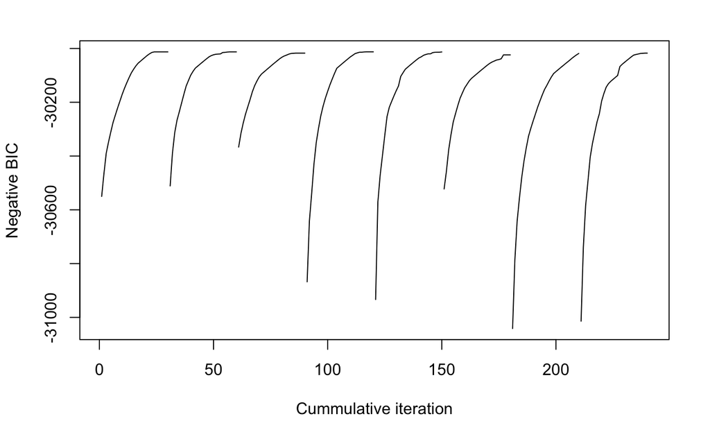

```r
plot(1:(itr*num.starts), -c(t(runs.bic)), xlab = "Cummulative iteration", ylab = "Negative BIC", type = "n")


for(i in 1:num.starts){
  lines((i-1)*itr + (1:itr), -runs.bic[i,])
}
```

```r
min = rep(0, times = num.starts)
for (i in 1:num.starts){
  min[i] = min(runs.bic[i, ])
}

which.min(min) #4th model has lowest BIC and converge -> choose model 4
```

```
[1] 4
```

```r
summary(lm(y~ ., data.sub[, runs[4, ] == 1]))
```

```
Call:
lm(formula = y ~ ., data = data.sub[, runs[4, ] == 1])

Residuals:
    Min      1Q  Median      3Q     Max
-180493  -11816     351   10325  180493

Coefficients:
                       Estimate Std. Error t value Pr(>|t|)
(Intercept)          -1.553e+06  1.199e+05 -12.951  < 2e-16 ***
LotArea               5.623e-01  8.036e-02   6.997 4.05e-12 ***
StreetPave            3.473e+04  1.179e+04   2.946 0.003270 **
NeighborhoodBlueste  -7.384e+03  1.919e+04  -0.385 0.700506
NeighborhoodBrDale   -2.829e+03  9.953e+03  -0.284 0.776275
NeighborhoodBrkSide  -6.215e+03  8.387e+03  -0.741 0.458807
NeighborhoodClearCr  -1.457e+04  8.916e+03  -1.634 0.102505
NeighborhoodCollgCr  -1.051e+04  7.128e+03  -1.475 0.140468
NeighborhoodCrawfor   9.849e+03  8.182e+03   1.204 0.228880
NeighborhoodEdwards  -1.762e+04  7.744e+03  -2.275 0.023039 *
NeighborhoodGilbert  -1.511e+04  7.547e+03  -2.001 0.045536 *
NeighborhoodIDOTRR   -1.275e+04  8.862e+03  -1.439 0.150426
NeighborhoodMeadowV  -3.959e+03  9.422e+03  -0.420 0.674380
NeighborhoodMitchel  -2.060e+04  7.966e+03  -2.586 0.009818 **
NeighborhoodNAmes    -1.778e+04  7.505e+03  -2.369 0.017979 *
NeighborhoodNoRidge   2.988e+04  8.102e+03   3.688 0.000234 ***
NeighborhoodNPkVill  -2.361e+02  1.084e+04  -0.022 0.982620
NeighborhoodNridgHt   2.327e+04  7.309e+03   3.184 0.001484 **
NeighborhoodNWAmes   -2.631e+04  7.751e+03  -3.395 0.000706 ***
NeighborhoodOldTown  -1.966e+04  8.131e+03  -2.418 0.015719 *
NeighborhoodSawyer   -1.767e+04  7.920e+03  -2.231 0.025834 *
NeighborhoodSawyerW  -1.417e+04  7.629e+03  -1.858 0.063375 .
NeighborhoodSomerst   2.076e+03  7.087e+03   0.293 0.769624
NeighborhoodStoneBr   3.594e+04  8.178e+03   4.394 1.20e-05 ***
NeighborhoodSWISU    -1.171e+04  9.407e+03  -1.245 0.213345
NeighborhoodTimber   -7.992e+03  8.132e+03  -0.983 0.325889
NeighborhoodVeenker   1.619e+03  1.025e+04   0.158 0.874548
Condition2Feedr      -9.465e+03  2.147e+04  -0.441 0.659378
Condition2Norm       -1.325e+03  1.871e+04  -0.071 0.943562
Condition2PosA        2.211e+04  3.217e+04   0.687 0.492039
Condition2PosN       -2.338e+05  2.639e+04  -8.860  < 2e-16 ***
```

[output cut: 29 more lines]

```
KitchenQualTA        -2.938e+04  3.927e+03  -7.481 1.30e-13 ***
GarageCars            7.153e+03  1.286e+03   5.563 3.18e-08 ***
ScreenPorch           3.308e+01  1.225e+01   2.700 0.007009 **
PoolArea              8.902e+01  1.802e+01   4.939 8.80e-07 ***
SaleConditionAdjLand  2.485e+04  1.355e+04   1.833 0.066965 .
SaleConditionAlloca   5.792e+03  8.299e+03   0.698 0.485392
SaleConditionFamily   2.521e+03  6.261e+03   0.403 0.687292
SaleConditionNormal   8.874e+03  2.684e+03   3.306 0.000971 ***
SaleConditionPartial  2.556e+04  3.833e+03   6.669 3.70e-11 ***
---
Signif. codes:  0 ‘***’ 0.001 ‘**’ 0.01 ‘*’ 0.05 ‘.’ 0.1 ‘ ’ 1

Residual standard error: 25090 on 1391 degrees of freedom
Multiple R-squared:  0.9049,    Adjusted R-squared:  0.9002
F-statistic: 194.6 on 68 and 1391 DF,  p-value: < 2.2e-16
```

# Part III.

Suppose X has a standard Normal distribution and you want to estimate $\mu=E[h(X)]$ with $h(x) = \frac{x^3}{1 − e^{2x}}$. Compute a standard Monte Carlo estimator based on n = 100,000 observations.

```r
h = function(x){x^3/ (1 - exp(2*x))}
n = 100000

set.seed(1)
x = rnorm(n, 0, 1)

mean(h(x)) #estimator
```

```
[1] -0.9097162
```

```r
#true value of E[h(X)]
integrand = function(x){
  h = x^3/ (1 - exp(2*x))
  f = 1/sqrt(2*pi) * exp(-x^2/2)
  return(h*f)
}
integrate(integrand, lower = -Inf, upper = Inf)
```

```
-0.8947444 with absolute error < 6.7e-07
```

```r
# the estimation is quite close to the true value
```